# Regresión Lineal

Probabilidad Aplicada

3602

# Introducción a la regresión lineal

La regresión lineal es una técnica estadística utilizada para modelar la relación entre dos variables cuantitativas: una variable dependiente (también llamada **variable respuesta** o **output**) y una variable independiente (o **predictora**). El objetivo es predecir el valor de la variable dependiente en función de la variable independiente.

En un **modelo de regresión lineal simple**, se busca ajustar una línea recta a un conjunto de datos, donde la ecuación general de esa línea es:

$$y=\beta_{0}+\beta_{1}x+\epsilon$$

$y$: Es la variable dependiente u output(respuesta), es decir, el valor que queremos predecir (ejemplo: peso, calificaciones).

$x$: Es la variable independiente o predictora, el valor que usamos para hacer la predicción (ejemplo: altura, horas de estudio).

$\beta_{0}$ : Es el **intercepto** o constante, que representa el valor de $y$ cuando $x=0$ (corte de la recta con el eje $y$)

$\beta_{1}$ : Es el coeficiente de pendiente o **slope**, que indica el cambio en $y$ por cada unidad de cambio en $x$ (representa la inclinación de la recta).

$\epsilon$: Es el **error** o **término residual**, que capta la variabilidad en $y$ que no se puede explicar por $x$.

# Ejemplos

- **Caso 1**: Relación entre el Peso y la Altura
- **Caso 2**: Relación entre la Calificación y las Horas de Estudio
- **Caso 3**: Relación entre las Ventas y el Gasto en Publicidad

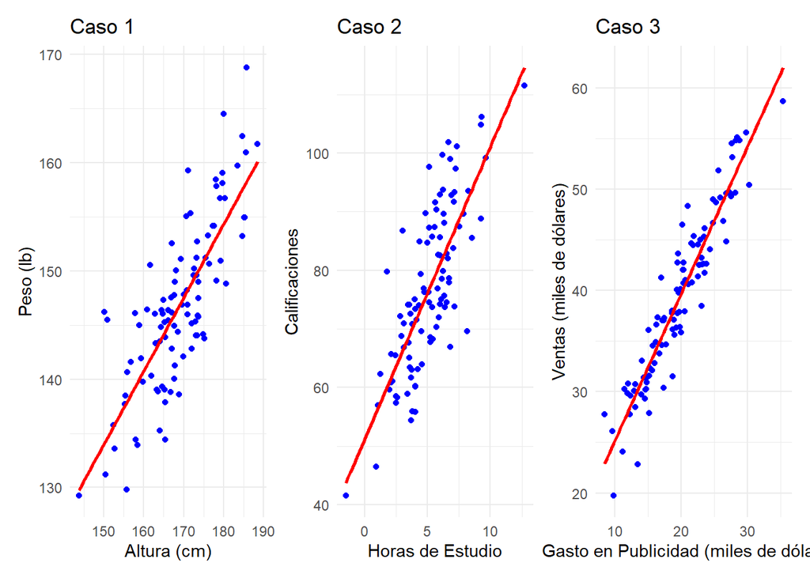

Ejemplos de Regresión Lineal

| Caso | Variable y | Variable x | Modelo de RL |
| --- | --- | --- | --- |
| 1 | Peso | Altura | $y=0.678x+32.2$ |
| 2 | Calificaciones | Horas de estudio | $y=5.00x+51.1$ |
| 3 | Ventas | Gasto en Publicidad | $y=1.45x+10.6$ |

# Elaboración de un Modelo de Regresión Lineal

Para ello utilizaremos las funciones **lm()** de R Base y la función **tidy()** del paquete **broom**. Utilizaremos los datos de la base **altura_peso.csv** que cargaremos previamente.

La estructura de la función **lm()** es:

**lm(y~x,data)**

y: variable explicada (dependiente, output).

x: variable explicativa (independiente, predictora).

data: dataset empleado.

En nuestro caso:

```r
modelo_caso_1 <- lm(Peso ~ Altura, data = altura_peso)
```

Ahora, vamos a pedir un resumen del modelo, usando la función **tidy()**

```r
res_mod_1 <- tidy(modelo_caso_1)
res_mod_1
```

```
## # A tibble: 2 x 5
##   term        estimate std.error statistic  p.value
##   <chr>          <dbl>     <dbl>     <dbl>    <dbl>
## 1 (Intercept)   32.2      8.89        3.62 4.63e- 4
## 2 Altura         0.678    0.0525     12.9  7.22e-23
```

# Interpretación del modelo

La fila 1 hace referencia a la ordenada al origen **intercepto**

La fila 2 hace referencia a la pendiente **slope**

La columna **estimate** proporciona los valores de $\hat{\beta_{0}}$ (intercepto) y $\hat{\beta_{1}}$ (slope):

- **(Inte~** es el Intercepto ($\beta_{0}$ ): Cuando x es 0, se espera que la variable dependiente sea 32.2.
- **x** es el slope ($\beta_{1}$): Un incremento de 1 unidad en x está asociado con un incremento de 0.678 en la variable dependiente.

Las columnas

- **std.error** (Errores estándar): Proporcionan información sobre la precisión de las estimaciones.
- **statistic** (Estadístico t): Es el valor del estadísitico t utilizado en la estimación de los parametros intercepto y slope.
- **p.value** (valores p): Es la probabilidad asociada a cada estadístico t utilizado. Un valor de $p<0.05$ se considera altamente significativo, lo que proporciona una muy buena estimación.

# Ecuación del modelo

$y=\hat{\beta_{0}}+\hat{\beta_{1}}x$

Una vez estimados los valores $\hat{\beta_{0}}=32.2$ y $\hat{\beta_{1}}=0.678$ reemplazamos los valores en la ecuación del modelo lineal: $y=0.678x+32.2$

## Ejercicio 1

Hallar los modelos de RL para los casos 2 y 3.

# ¿Cual es el grado de relación lineal entre dos variables?

Esto se infiere de la **correlación**. La correlación es una medida estadística que indica el grado en que dos variables están relacionadas.

El coeficiente de correlación, comúnmente representado como $R$ puede variar entre -1 y 1:

$R=1$: Indica una correlación positiva perfecta (a medida que una variable aumenta, la otra también lo hace).

$R=−1$: Indica una correlación negativa perfecta (a medida que una variable aumenta, la otra disminuye).

$R=0$: Indica que no hay correlación lineal entre las variables.

**Coeficiente de Determinación $R^2$**

El **coeficiente de determinación**, es una medida que se utiliza para evaluar la calidad del ajuste del modelo de regresión. Se interpreta como el porcentaje de la variabilidad de la variable dependiente que se puede explicar por la variable independiente en el modelo.

Interpretación de $R^2$

$R^2=0.75$ indica que el $75\%$ de la variabilidad en la variable dependiente se puede explicar por la variable independiente. Esto sugiere un buen ajuste del modelo.

$R^2=0.25$ indica que solo el $25\%$ de la variabilidad se explica, lo que sugiere que el modelo no ajusta bien los datos.

## Determinación del coeficiente de correlación en R

Para hallar el coeficiente de correlación $R^2$ en R utilizaremos la función **summary()** de R Base.

Primero, aplicamos **summary()** a nuestro modelo:

```r
sum_mod_1 <- summary(modelo_caso_1)
```

Luego, definimos la cantidad **R_cuad_1** que será extraída del summary de nuestro modelo.

```r
R_cuad_1 <- sum_mod_1$r.squared
R_cuad_1
```

```
## [1] 0.6297598
```

Conseguimos $R^2=0.6297598$. Esto significa que aproximadamente el $63\%$ de la variabilidad en la variable y (peso) se puede explicar por la variable x (altura).

# Representación gráfica de los datos, la recta de RL (modelo) y el $R^2$.

```r
graf_mod_1 <- ggplot(altura_peso, aes(x = Altura, y = Peso)) + #marco de datos
  geom_point(color = "blue") + #scatter plot (gráfico de dispersion)
  geom_smooth(method = "lm", color = "red", se = FALSE) + #recta del modelo
  labs(title = "Relación entre Altura y Peso",
       subtitle = paste("R² =", round(R_cuad_1, 3)),  # Muestra R² en el gráfico
       x = "Altura (cm)",
       y = "Peso (lb)")  +#etiquetas
  theme_minimal() #estilo del gráfico
```

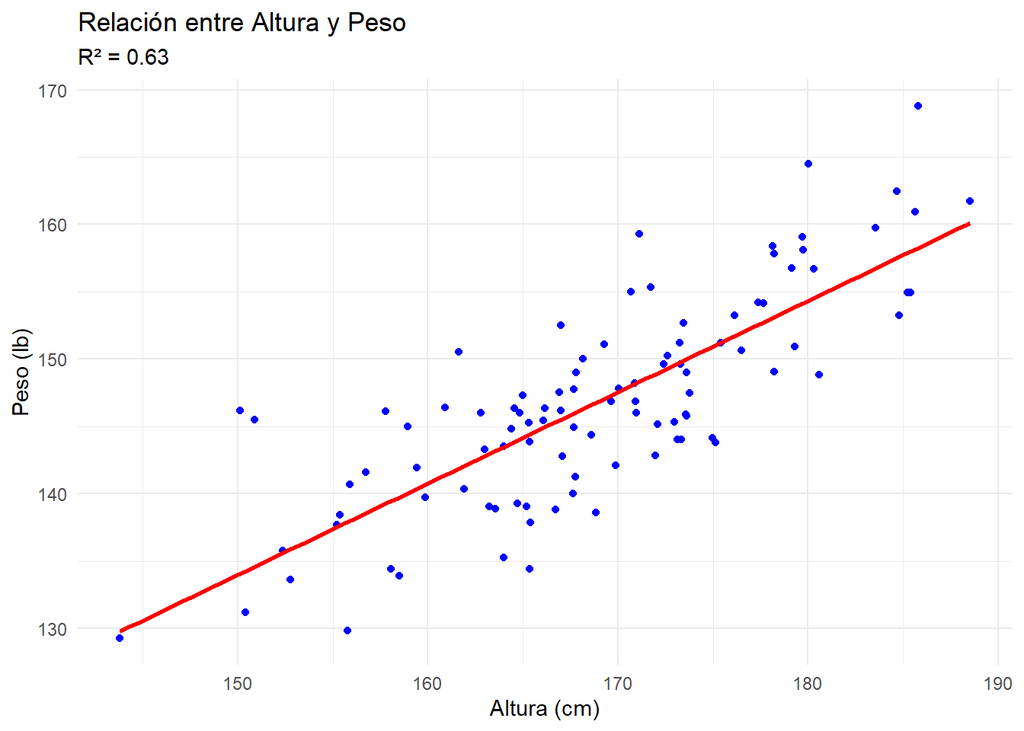

```r
graf_mod_1
```

## Ejercicio 2

1. Hallar los coeficientes de correlación para los modelos del ejercicio 1.
2. Realizar un gráfico de dispersión, que incluya la recta del modelo y el valor de $R^2$ para cada modelo del ejercicio 1.

## Ejercicio 3

Determinar un modelo de regresión lineal (gráfico y coeficiente de correlación incluido) para cada para de variables que considere apropiadas de la base **insurance**.